# False Positives

Pietro Franceschi

4 February 2019

This first demo deals with “random organization”. Asw we discussed in the lecture, an experiment is always performed on a subset of the population, so a measured “organization”

- can mirror a population level characteristics
- can be the result of a “unlucky” sampling

To undertand the second point, just consider an hypothetic sampling of the human population made by an extraterrestrial entity. If he random sample a couple of humans, it will likely conclude that we are all chinese!

Let’s make a more scientific example. Let’s create a fake proteomics experiment where I’m measuring the concentration of 1000 proteins on a group of 20 samples. And let’s suppose that I want to study the correlation between the different proteins to infer new regulatory networks …

To simulate a dummy experiment I will fill my expression matrix with random numbers …

```r
## Random expression data matrix

DM <- matrix(rnorm(20000), nrow = 20)
dim(DM)
```

```
## [1]   20 1000
```

That’s the data matrix. Is there true organization there? NO!

Let’s calculate the correlation among the different proteins …

```r
mycorr <- cor(DM)
dim(mycorr)
```

```
## [1] 1000 1000
```

Now we get only the upper triangle of the matrix and we look to the distribution of the correlation coefficients

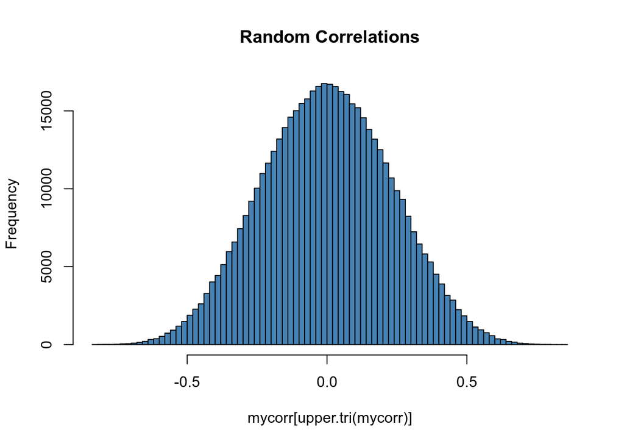

```r
hist(mycorr[upper.tri(mycorr)],
     col = "steelblue",
     breaks = 100,
     main = "Random Correlations")
```

Unexpectedly ( ;-) ) … we also have high correlation variables! The code below gives you the indices of the variables showing high correlation, excluding the 1s

```r
highcorrid <- which(mycorr > 0.8 & mycorr != 1, arr.ind = TRUE)
highcorrid
```

```
##       row col
##  [1,]  50  45
##  [2,]  45  50
##  [3,] 207 159
##  [4,] 772 171
##  [5,] 737 185
##  [6,] 159 207
##  [7,] 691 284
##  [8,] 708 298
##  [9,] 962 354
## [10,] 712 367
## [11,] 284 691
## [12,] 298 708
## [13,] 367 712
## [14,] 185 737
## [15,] 171 772
## [16,] 354 962
```

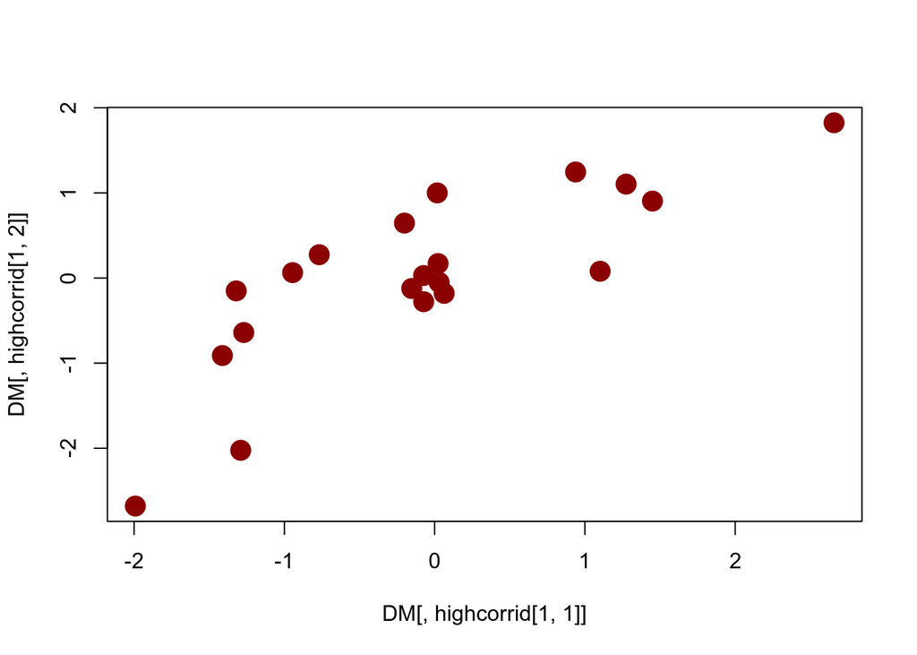

```r
plot(DM[,highcorrid[1,1]],DM[,highcorrid[1,2]], col = "darkred", pch = 19, cex = 2)
```

Here the presence of high correlation is clear!!! But this correlation does not have a “biological” origin … so it does not represent a truly scientific result …